# Time Series – Group Project || Prof. Francesca Lipari

## (b)

With fixed seasonality and a window for the trend of 5:

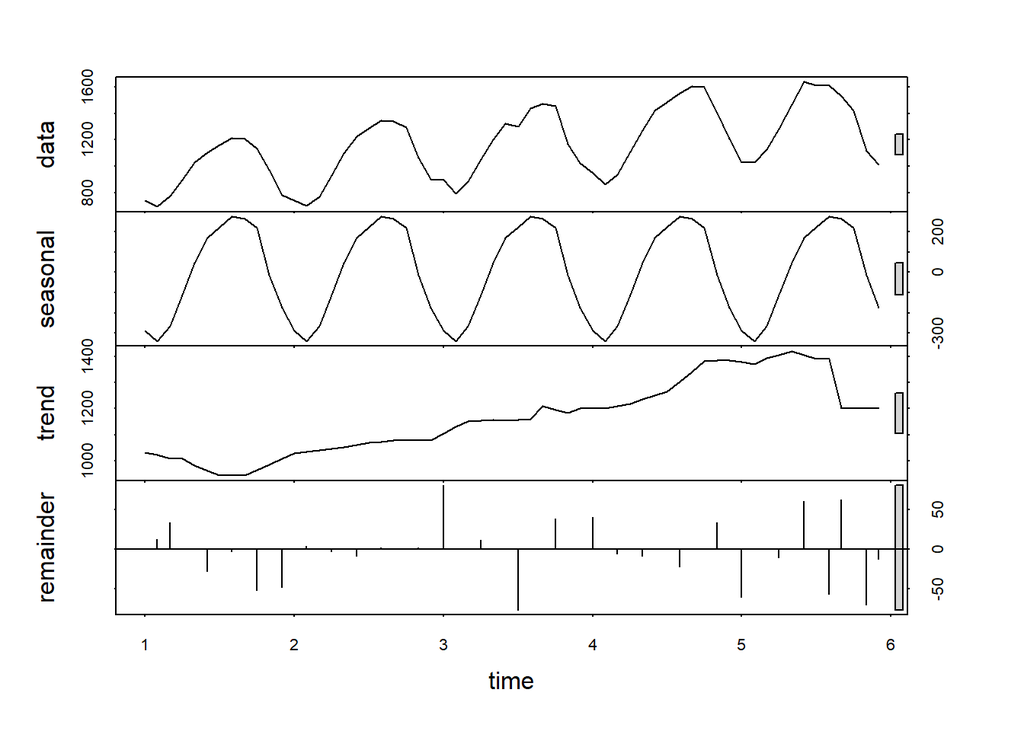

Plastics STL decomposition

```r
fit <- stl(plastics, t.window = 5, s.window = "periodic", robust = T)
plot(fit)
```

With changing seasonality (s.window = 13):

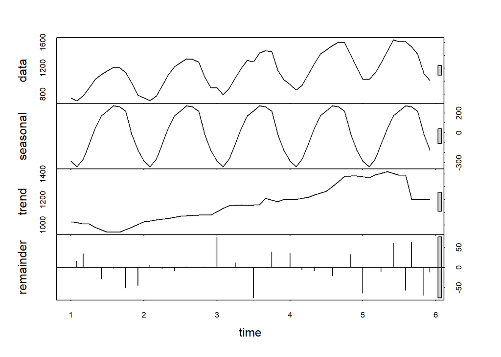

Plastics STL decomposition 2

```r
fit2 <- stl(plastics, t.window = 5, s.window = 13, robust = T)
plot(fit2)
```

## (c)

We can see a strong seasonality component and a positive trend. As explained before, both decompositions have a trend with a negative slope at the end, but this is due to the abrupt end of the series and should not be considered true.

## (d)

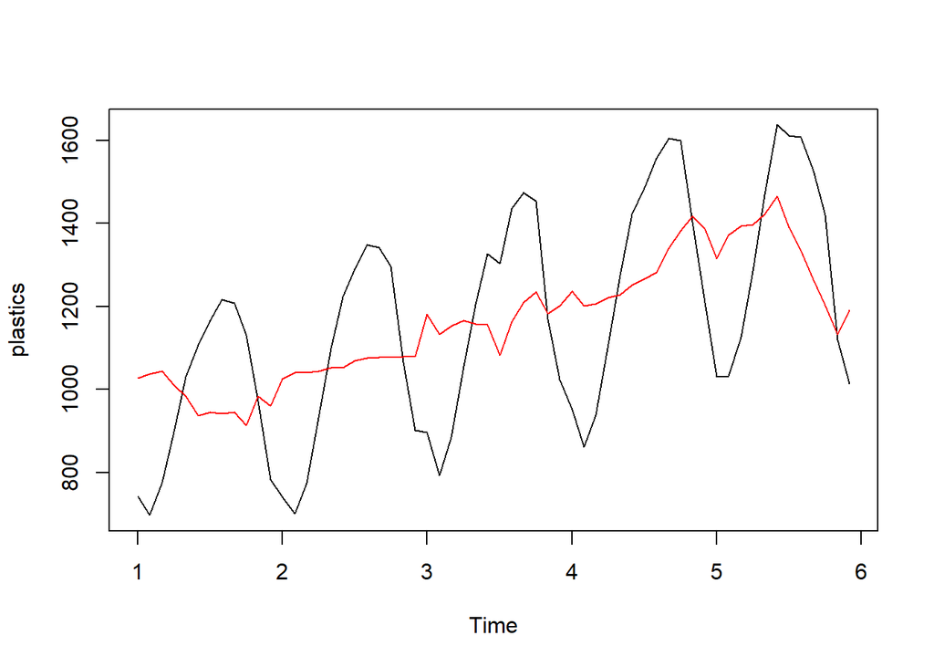

```r
seadj <- seasadj(fit2)
plot(plastics)
lines(seadj, col = "red")
```

We can see that the data has been successfully deseasonalized.

## (e)

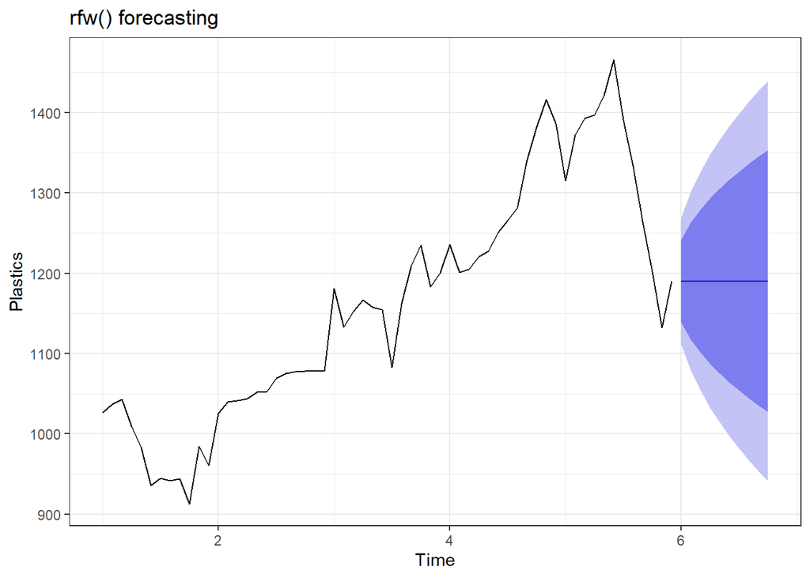

Forecast with seasonally adjusted data

```r
autoplot(seadj) +
    autolayer(rwf(seadj), PI = TRUE) +
    xlab("Time") + ylab("Plastics") + ggtitle("rfw() forecasting") + theme_bw()
```

## (f)

The forecast on a decomposed time series, we forecast the seasonal component and the seasonally adjusted component separately.

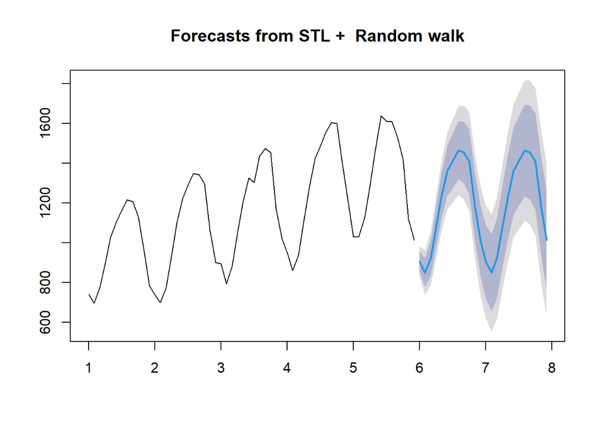

Forecast on the original scale

```r
fcast <- forecast::forecast(fit2, method = "naive")
plot(fcast)
```

# Exercise 6

> Use the monthly Australian short-term overseas visitors data, May 1985-April 2005 (Data set visitors).
> 1. With the help of the appropriate graphical representation, please describe the main features of the series.
> 2. Forecast the next two years using Holt-Winters method according to the features you found in the previous point. Justify your choice.
> 3. Experiment with making the trend exponential and/or damped. Do you see any difference? Justify your answer.
> 4. Now fit each of the following models to the same data:
> 1. an ETS model
> 2. an additive ETS model applied to a Box-Cox transformed series
> 3. an STL decomposition applied to the Box-Cox transformed data followed by an ETS model applied to the seasonally adjusted (transformed) data. Plot all the forecasts together.
> 5. For each model, look at the residual diagnostics and compare the forecasts for the next two years. Which do you prefer?

We take the data `visitors` from the `fpp2` package. It exhibits the following form:

```r
head(visitors, 5 * 12)
```

```
##        Jan   Feb   Mar   Apr   May   Jun   Jul   Aug   Sep   Oct   Nov   Dec
## 1985                          75.7  75.4  83.1  82.9  77.3 105.7 121.9 150.0
## 1986  98.0 118.0 129.5 110.6  91.7  94.8 109.5 105.1  95.0 130.3 156.7 190.1
## 1987 139.7 147.8 145.2 132.7 120.7 116.5 142.0 140.4 128.0 165.7 183.1 222.8
## 1988 161.3 180.4 185.2 160.5 157.1 163.8 203.3 196.9 179.6 207.3 208.0 245.8
## 1989 168.9 191.1 180.0 160.1 136.6 142.7 175.4 161.4 149.9 174.1 192.7 247.4
## 1990 176.2 192.8 189.1 181.1
```

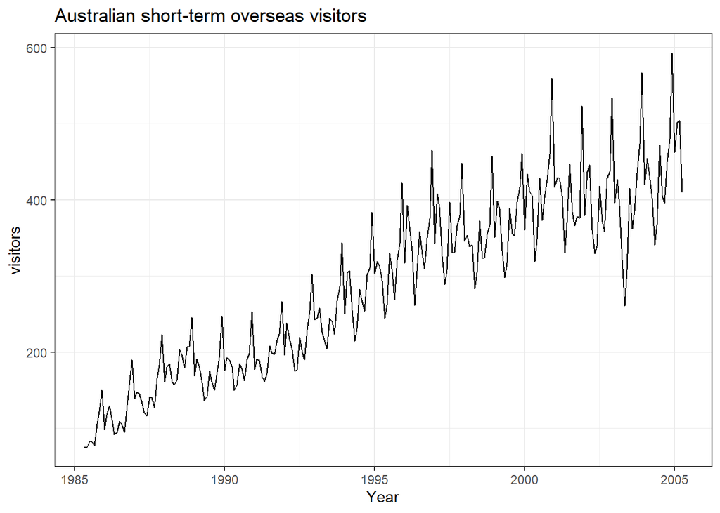

Time series plot of the `visitors` dataset.

```r
autoplot(visitors, ylab = "visitors", xlab = "Year",
         main="Australian short-term overseas visitors") + theme_bw()
```

## (a)

We note a strong seasonality component with no apparent cyclic behavior which can be more prominently shown in a seasonal plot or a polar plot. In it we note that there is a yearly period with a clear anual pattern. There seems to be also a positive tendency, apparently linear.

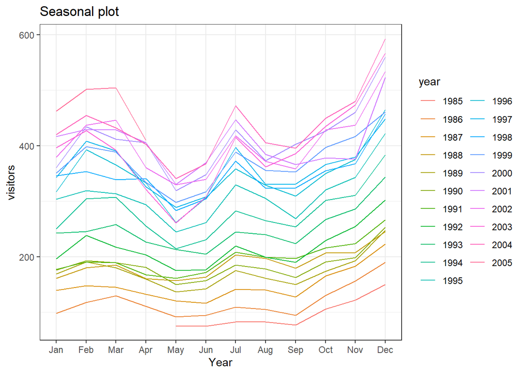

Seasonal plot for the `visitors` dataset.

```r
ggseasonplot(visitors, ylab = "visitors", xlab = "Year",
             main = "Seasonal plot") + theme_bw()
```

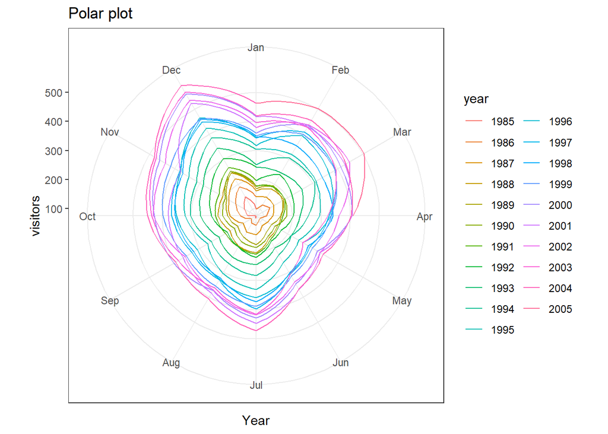

Seasonal polar plot for the `visitors` dataset.

```r
ggseasonplot(visitors, ylab = "visitors", xlab = "Year",
             polar = TRUE, main = "Polar plot") + theme_bw()
```

Moreover, in the corresponding ACF plot we observe a slowly decreasing autocorrelation, hinting tendency, combined with periodicity in the peaks, signing mark of seasonality with a 12 month period.

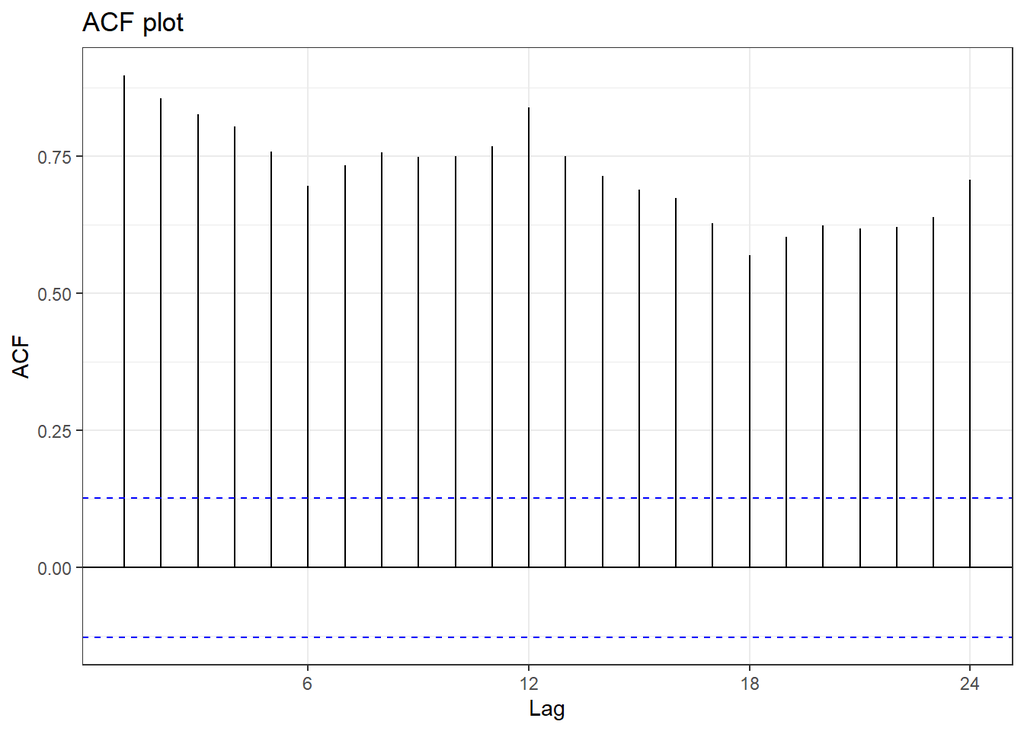

Autocorrelations of the `visitor` dataset. Lags are in months.

```r
ggAcf(visitors) + ggtitle("ACF plot") + theme_bw()
```

Let us plot two decomposition graphs, one additive and another multiplicative, and then decide which of them better fits our data.

We see the additive one leads to a distribution of the remainder which does appear to have heteroskedasticity. More precisely, at the later years there are quite prominent peaks compared to other time ranges. In the center there is kind of a dip.

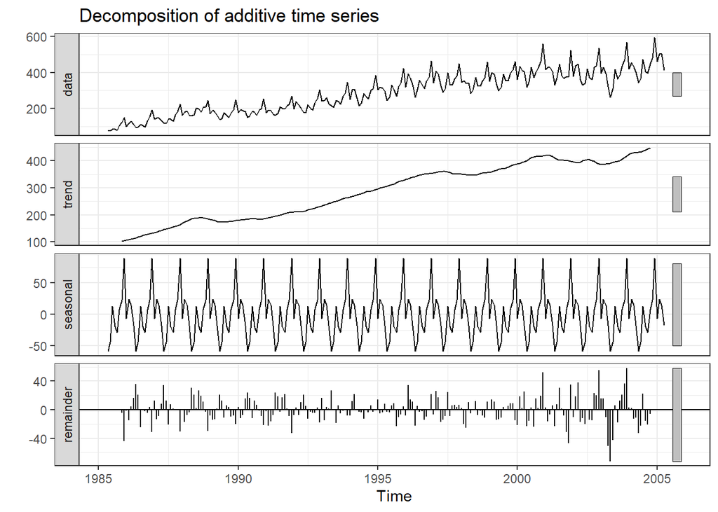

Classical decomposition of the `visitors` data set assuming the underlaying model is additive on the tendency and errors.

```r
autoplot(decompose(visitors, "additive")) + theme_bw()
```

On the other hand, with the multiplicative decomposition we observe a more even distribution of remainders, which do not look distributed following any pattern, without clear differences between areas.

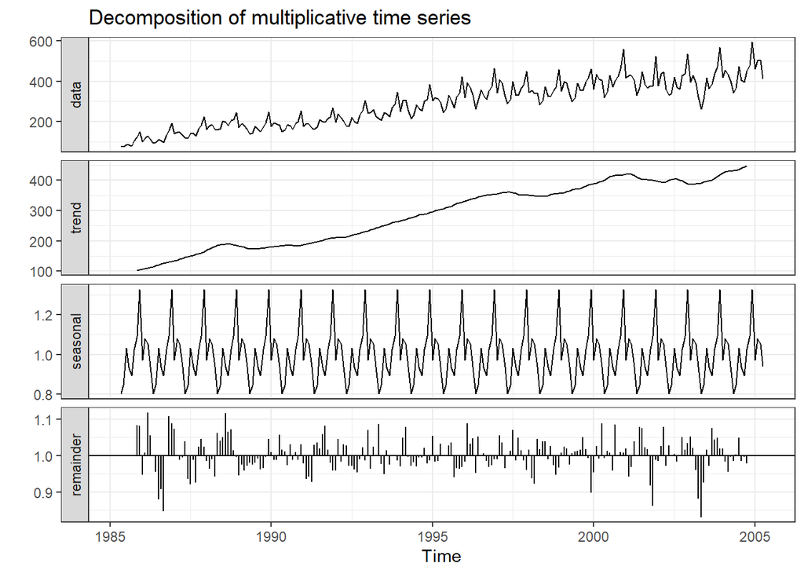

Classical decomposition of the `visitors` data set assuming the underlaying model is multiplicative on the tendency and errors.

```r
autoplot(decompose(visitors, "multiplicative")) + theme_bw()
```

With these facts in mind, we decide the latter, the multiplicative model, better fits our data.

## (b)

As discussed before, we will use a multiplicative seasonal decomposition when performing a Holter-Winters fit. We also decide that, for both, performance of the forecast and numerical cost, we will limit the data used for forecasting from the year 2000 onwards.

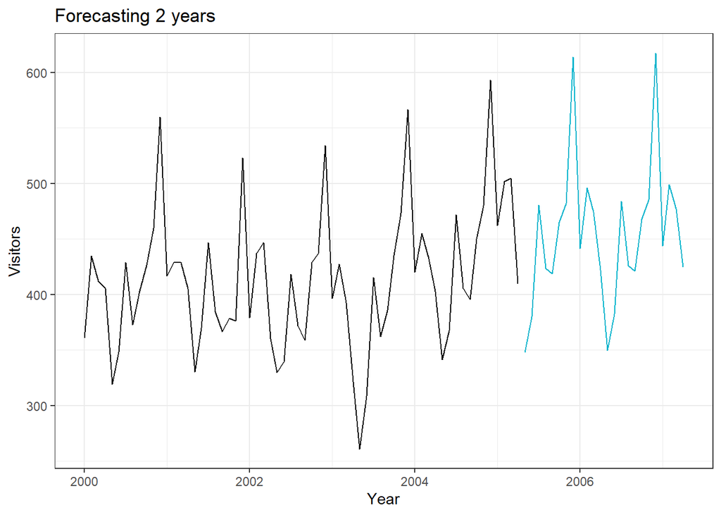

Forecast of two years using multiplicative Holter-Winters as the the forecasting model.

```r
vis_cut <- window(visitors, start = 2000)
fit_hw  <- hw(vis_cut, seasonal = "multiplicative", h = 2 * 12)

autoplot(window(vis_cut, start = 1995)) +
    autolayer(fit_hw, PI = FALSE, col = "deepskyblue4") +
    xlab("Year") + ylab("Visitors") + ggtitle("Forecasting 2 years") + theme_bw()
```

We see that the previously made decision does indeed seem grounded as the forecast, at least on the naked eye, does look as a good candidate.

## (c)

We are now tasked with testing the forecast with different options. Taking the same Holter-Winters multiplicative model, we experiment by choosing exponential trend, damped trend and both of them at once. If we plot them together we see that all of them do *a priori* a good job in forecasting the following two years. In this regards, the exponential trend offers more volatile extrema, while the damped offers the smallest. The curve with both of them does seem like a middle compromise between the exponential and damped models.

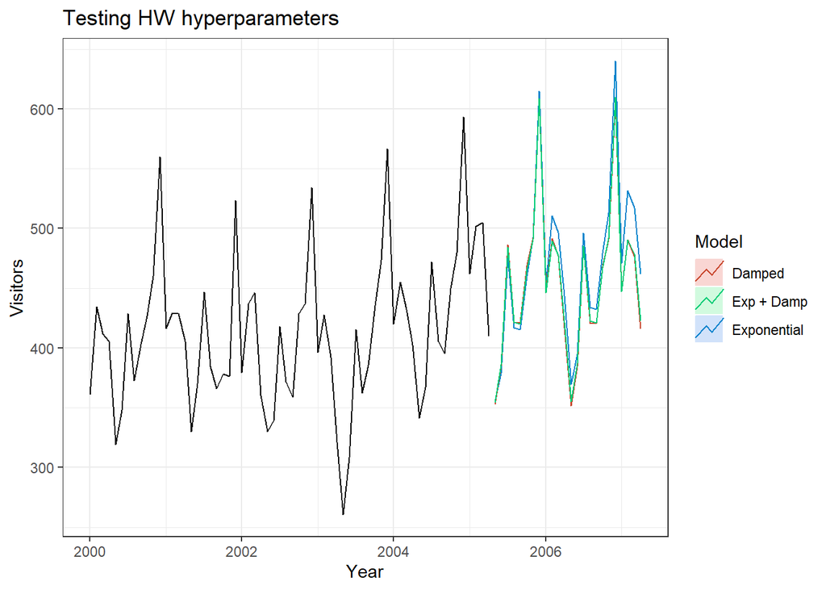

Forecast of two years using multiplicative Holter-Winters as the the forecasting model with different modifications to the tendency component: exponential, damped and both combined.

```r
fit_exp  <- hw(vis_cut, seasonal = "multiplicative", h = 2 * 12, exponential = TRUE)
fit_dam  <- hw(vis_cut, seasonal = "multiplicative", h = 2 * 12, damped = TRUE)
fit_both <- hw(vis_cut, seasonal = "multiplicative", h = 2 * 12,
               exponential = TRUE, damped = TRUE)

autoplot(window(vis_cut, start = 2000)) +
    autolayer(fit_exp,  PI = FALSE, series = "Exponential") +
    autolayer(fit_dam,  PI = FALSE, series = "Damped") +
    autolayer(fit_both, PI = FALSE, series = "Exp + Damp") +
    xlab("Year") + ylab("Visitors") + ggtitle("Testing HW hyperparameters") +
    guides(colour = guide_legend(title ="Model")) + theme_bw()
```

It seems clear that by eyeballing we will not be able to properly select one of these models as the most appropiate. Hence we resort to metrics such as AIC, AICc and BIC. Looking at them it seems that the previous modifications do indeed improve on the forecasting. Among them, the exponential and damped takes the edge over the just damped one by a slight margin, giving us an indication that reduced extrema better forecasts our time series.

```r
knitr::kable(data.frame(
    "Default"  = c(fit_hw$model$aic,   fit_hw$model$aicc,   fit_hw$model$bic),
    "Exp"      = c(fit_exp$model$aic,  fit_exp$model$aicc,  fit_exp$model$bic),
    "Damped"   = c(fit_dam$model$aic,  fit_dam$model$aicc,  fit_dam$model$bic),
    "Exp.Damp" = c(fit_both$model$aic, fit_both$model$aicc, fit_both$model$bic),
    row.names = c("AIC", "AICc", "BIC")
))
```

|  | Default | Exp | Damped | Exp.Damp |
| --- | --- | --- | --- | --- |
| AIC | 700.4753 | 697.5382 | 686.5541 | 686.0368 |
| AICc | 713.7797 | 710.8426 | 701.7541 | 701.2368 |
| BIC | 737.1763 | 734.2392 | 725.4140 | 724.8967 |

## (d)

This is a just computational part in which are tasked with fitting three models:

```r
fit_ets <- ets(vis_cut)
summary(fit_ets)
```

```
## ETS(A,N,A)
##
## Call:
##  ets(y = vis_cut)
##
##   Smoothing parameters:
##     alpha = 0.7188
##     gamma = 1e-04
##
##   Initial states:
##     l = 409.9759
##     s = 139.4822 30.3792 10.6118 -31.1065 -32.0805 26.2524
##            -63.0939 -92.4909 -30.097 19.5845 33.0686 -10.5098
##
##   sigma:  21.1111
##
##      AIC     AICc      BIC
## 670.7438 680.7438 703.1270
##
## Training set error measures:
##                     ME     RMSE      MAE        MPE     MAPE      MASE
## Training set 0.8927493 18.65976 15.50572 0.07119266 3.850555 0.4952687
##                     ACF1
## Training set -0.02160021
```

2. An additive ETS model with Box-Cox transformed data. Here we impose the additivity of the model but let the algorithm to determine the correct $\lambda$ needed for the transformation.

```r
fit_bc  <- ets(vis_cut, model = "AAA", lambda = "auto")
summary(fit_bc)
```

```
## ETS(A,A,A)
##
## Call:
##  ets(y = vis_cut, model = "AAA", lambda = "auto")
##
##   Box-Cox transformation: lambda= -0.2557
##
##   Smoothing parameters:
##     alpha = 0.7475
##     beta  = 0.0066
##     gamma = 2e-04
##
##   Initial states:
##     l = 3.0674
##     b = 5e-04
##     s = 0.0601 0.0148 0.0073 -0.0116 -0.0117 0.0174
##            -0.0316 -0.0537 -0.016 0.0111 0.0174 -0.0035
##
##   sigma:  0.0124
##
##       AIC      AICc       BIC
## -279.9891 -266.6848 -243.2881
##
## Training set error measures:
##                     ME     RMSE     MAE        MPE    MAPE     MASE        ACF1
## Training set 0.2552246 19.94666 16.4712 -0.1392087 4.07376 0.526107 -0.04972495
```

3. An additive ETS model applied to the STL-seasonality-freed Box-Cox transformed time series. Again, we let the algorithm decide the appropriate transformation parameter. Nonetheless, we fix the seasonality period as 12 months.

```r
fit_stl <- stlm(vis_cut, s.window = 12, method = "ets", lambda = "auto")
summary(fit_stl)
```

```
##               Length Class  Mode
## stl           256    mstl   numeric
## model          19    ets    list
## modelfunction   1    -none- function
## lambda          1    -none- numeric
## x              64    ts     numeric
## series          1    -none- character
## m               1    -none- numeric
## fitted         64    ts     numeric
## residuals      64    ts     numeric
```

## (e)

At last, we are tasked with comparing these last three approaches to see which of them performs better. To do so, we first plot all of them together and see whether there is some significant difference between them visible by the naked eye.

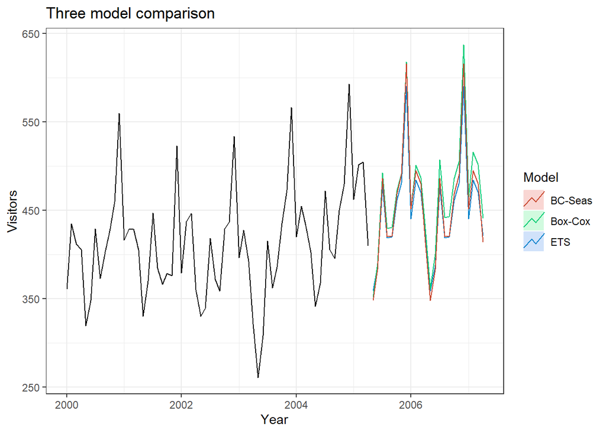

```r
autoplot(vis_cut) +
    autolayer(forecast::forecast(fit_ets, h = 2 * 12),
              PI = FALSE, series = "ETS") +
    autolayer(forecast::forecast(fit_bc,  h = 2 * 12),
              PI = FALSE, series = "Box-Cox") +
    autolayer(forecast::forecast(fit_stl, h = 2 * 12),
              PI = FALSE, series = "BC-Seas") +
    xlab("Year") + ylab("Visitors") + ggtitle("Three model comparison") +
    guides(colour = guide_legend(title ="Model")) + theme_bw()
```

Again, just by looking at the graph we cannot tell which of them better describe our time series. Thus we resort to accuracy metrics. More exactly, we will be using the `tsCV` function which performs cross-validations and return a vector of residuals. We then sum the square residuals and declare the one with the smallest sum as the most suitable for our case. We also plot them to have visual feedback on the magnitude and whether they resemble white noise, which all of them do. This happens for the last of the models, which performed slightly better than the rest, highlighting the vital importance of taking the necessary preprocessing steps before fitting and forecasting.

```r
f1 <- function(y, h) { forecast::forecast(ets(y, model = "MAM"), h = h) }
f2 <- function(y, h) { forecast::forecast(ets(y, model = "AAA",
                                          lambda = "auto"), h = h) }
f3 <- function(y, h) { forecast::forecast(
  stlm(y, s.window = 12, method = "ets", lambda = "auto"), h = h) }
e1 <- tsCV(vis_cut, f1, h = 1)
e2 <- tsCV(vis_cut, f2, h = 1)
e3 <- tsCV(vis_cut, f3, h = 1)

# e3 starts at 2002, we cut them
e1 <- window(e1, start = 2002)
e2 <- window(e2, start = 2002)
e3 <- window(e3, start = 2002)

c(
    "ETS"     = sqrt(mean(e1 ^ 2, na.rm = TRUE)),
    "Box-Cox" = sqrt(mean(e2 ^ 2, na.rm = TRUE)),
    "BC-Seas" = sqrt(mean(e3 ^ 2, na.rm = TRUE))
)
```

```
##      ETS  Box-Cox  BC-Seas
## 27.66942 25.85527 23.92951
```

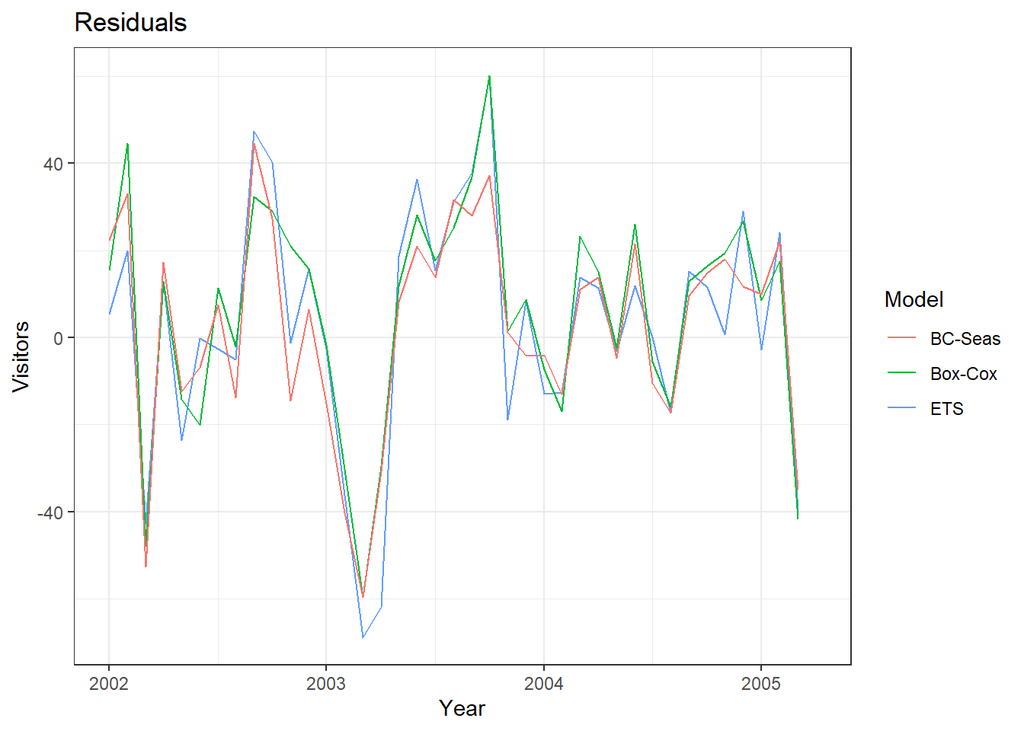

```r
autoplot(e1, series = "ETS") +
    autolayer(e2, series = "Box-Cox") +
    autolayer(e3, series = "BC-Seas") +
    xlab("Year") + ylab("Visitors") + ggtitle("Residuals") +
    guides(colour = guide_legend(title ="Model")) + theme_bw()
```

# Exercise 7

> Data set **books** contains the daily sales of paperback and hardcover books at the same store. The task is to forecast the next four days sales for paperback books (data set **books**).
> 1. Plot the series and discuss the main features of the data.
> 2. Use simple exponential smoothing with the **ses** function (setting `initial="simple"`) and explore different values of $\alpha$ for the paperback series. Record the within-sample SSE for the one-step forecasts. Plot SSE against $\alpha$ and find which values of $\alpha$ works best. What is the effect of $\alpha$ on the forecasts?
> 3. Now let **ses** select the optimal value of $\alpha$. Use this value to generate forecasts for the next four days. Compare your results with (b).

## (a)

As said in the problem statement, the data set *books* contains the daily sales of paperback and hardcover books:

```r
head(books, 3)
```

```
## Time Series:
## Start = 1
## End = 3
## Frequency = 1
##   Paperback Hardcover
## 1       199       139
## 2       172       128
## 3       111       172
```

We can see that the frequency is 1, so there’s no seasonality in the data.

The interest lies in the paperback books so we’re going to save the data related to the paperback books sales in a new variable called `paperback`.

```r
paperback <- books[,1]
```

Now, we do a time plot for the data:

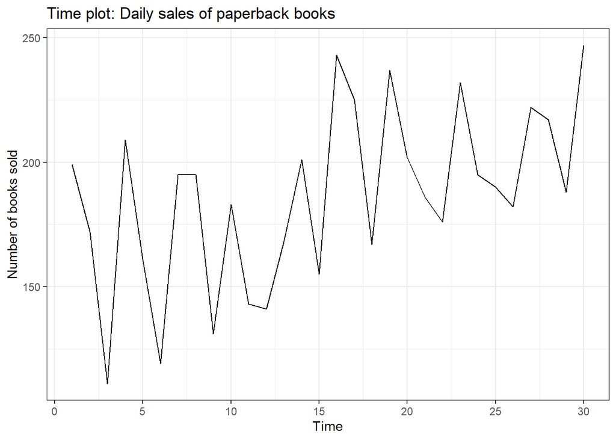

Time plot for the daily sales of paperback books.

```r
autoplot(paperback, main = "Time plot: Daily sales of paperback books",
        xlab = "Time",
        ylab = "Number of books sold") + theme_bw()
```

At first glance we can see a possible positive trend. We could also talk about the possible existence of cycles but, as it is said in the theory of the subject: *“The duration of a cycle extends over longer period of time, usually two or more years. two or more years.”*, and, in this case, we would be talking about cycles of only a few days, so we may have doubts as to whether this is really a cyclical behavior.

Next, we’re going to plot the ACF:

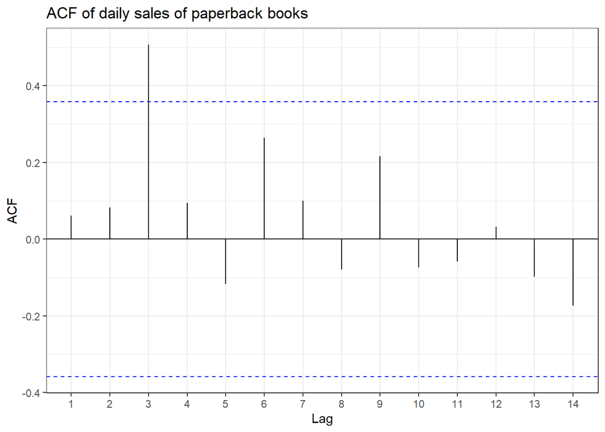

ACF of daily sales of paperback books.

```r
ggAcf(paperback) + ggtitle("ACF of daily sales of paperback books") + theme_bw()
```

The ACF does not seem to show the presence of a positive trend in the data. The high value for r~3 may indicate cycles of length 3, but it is really hard to tell.

We have a little theory about this: maybe the days are not necessarily from Monday to Sunday, and it is from Monday to Saturday (1 -> Monday, 6 -> Saturday, 7 -> Monday …) and that both Wednesdays and Saturdays there are offers, which makes sales on those days go up. This is probably not the case, but it is a silly explanation we found that may explain these “cycles”.

Now, looking to the lagplots:

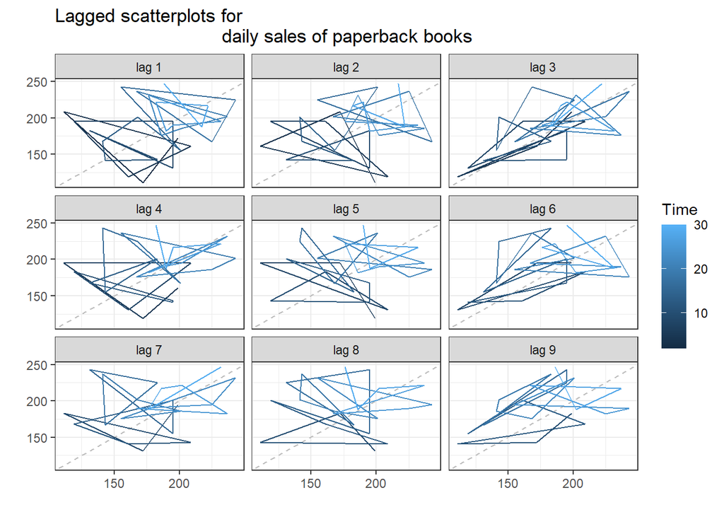

Lagged scatterplots for daily sales of paperback books.

```r
par(mfrow= c(1,2))
gglagplot(paperback) + ggtitle("Lagged scatterplots for
                               daily sales of paperback books") +
  theme_bw()
```

We cannot see the presence of cycles.

## (b)

We start by generating 101 alphas (from 0 to 1 with a step of 0.01) and computing the within-sample SSE for the one-step forecasts for every of these alphas.

```r
alphas <- seq(0,1,0.01)
fits   <- lapply(alphas, function(alpha) {ses(paperback, initial = "simple",
                                              h = 1, alpha = alpha)})
SSEs   <- lapply(fits, function(fit) {sum(fit$residuals^2)})
```

Now, we plot each alpha value with its corresponding SSE:

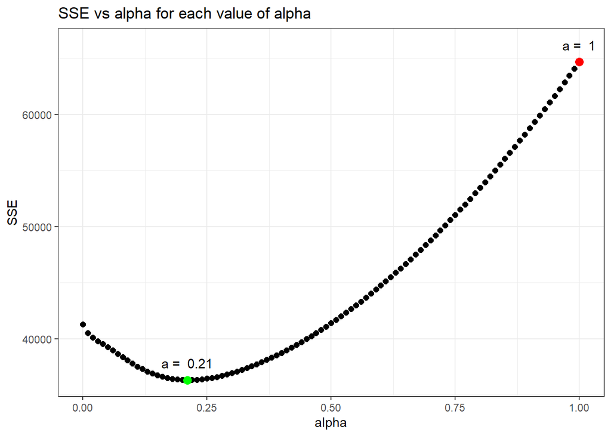

SSE vs alpha for each value of alpha.

```r
df               <- data.frame(alphas=alphas, SSEs=unlist(SSEs))
df$label         <- paste("a = ",alphas)
best_found_alpha <- df[which.min(df$SSEs),1]

ggplot(data = df, aes(x = alphas, y = SSEs)) +
    geom_point(color="black", size=2) +
    geom_point(data = df[which.min(df$SSEs),], color="green",
               size=3) +
    geom_point(data = df[which.max(df$SSEs),], color="red",
               size=3) +
    geom_text(data = rbind(df[which.min(df$SSEs), ], df[which.max(df$SSEs),]),
              aes(alphas,SSEs+1500, label=label)) +
    xlab("alpha") +
    ylab("SSE") +
    ggtitle("SSE vs alpha for each value of alpha") +
    theme_bw()
```

According to the graph, the best $\alpha$ is 0.21 and the worst is 1. This makes sense as the SES model with an $\alpha=1$ is no more than a naive model.

Answering to *“What is the effect of $\alpha$ on the forecasts?”*, $\alpha$ is changing the weight attached to the observations, with an small $\alpha$ (close to 0) giving more weight to the observations from the more distant past and a big $\alpha$ giving more weight to recent observations. As the model is exponential, we can say that $\alpha=0.21$ (the best $\alpha$ found according to the criteria of minimizing the SSE among all the $\alpha$ tested) is giving importance both to instances from the near and for the far past.

## (c)

To let the `ses` function select the optimum value for $\alpha$ by itself, we need to leave the alpha parameter empty.

```r
fit_auto_alpha <- ses(paperback, initial = "simple", h = 4, alpha = NULL)
fit_auto_alpha$model
```

```
## Simple exponential smoothing
##
## Call:
##  ses(y = paperback, h = 4, initial = "simple", alpha = NULL)
##
##   Smoothing parameters:
##     alpha = 0.2125
##
##   Initial states:
##     l = 199
##
##   sigma:  34.7918
```

The value found by the function is $\alpha=0.2125$, really close to the value found by us in the previous section.

We plot the forecast with this new $\alpha$:

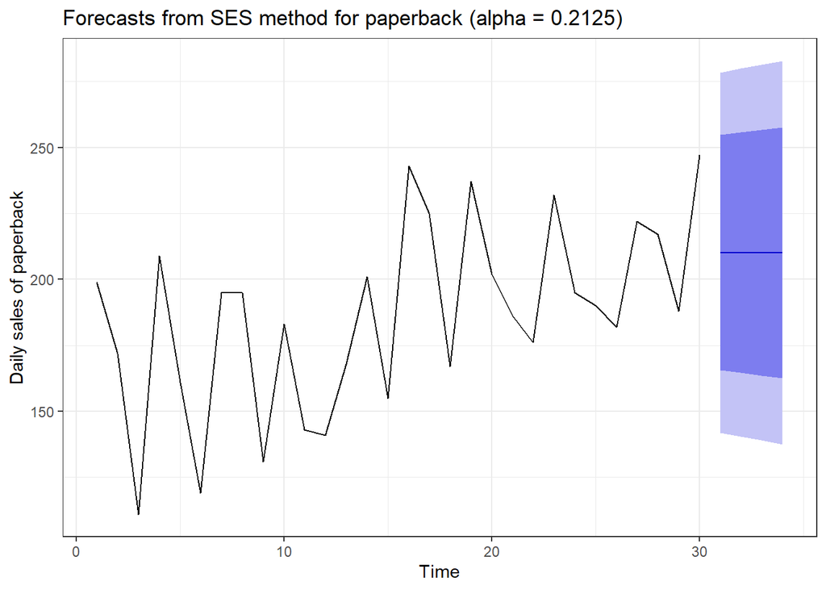

Forecasts from SES method for paperback (alpha = 0.2125)

```r
plot_auto_alpha <- autoplot(fit_auto_alpha,
        main = "Forecasts from SES method for paperback (alpha = 0.2125)",
        xlab = "Time",
        ylab = "Daily sales of paperback") + theme_bw()
plot_auto_alpha
```

Comparing the forecasting with both alphas we can see that they are pretty much the same, being able to observe minimal differences.

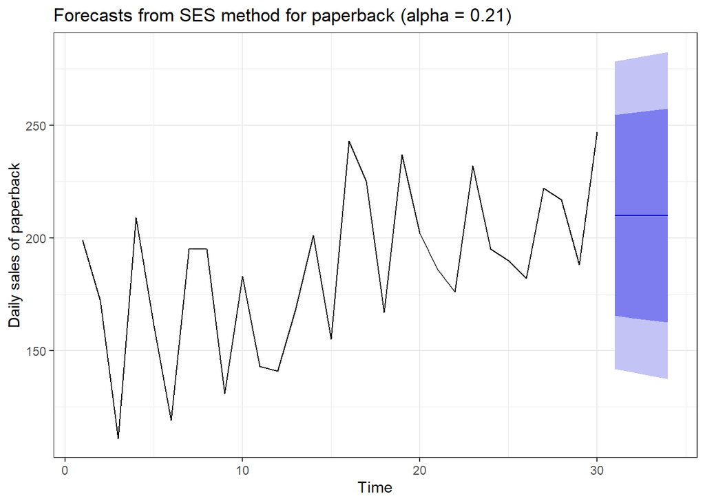

Forecasts from SES method for paperback (alpha = 0.21)

```r
plot_found_alpha <- autoplot(ses(paperback, initial = "simple", h = 4,
                                 alpha = best_found_alpha),
        main = "Forecasts from SES method for paperback (alpha = 0.21)",
        xlab = "Time",
        ylab = "Daily sales of paperback") + theme_bw()
plot_found_alpha
```